# Partie 2 - Analyse en aval : diversité, statistiques et interprétation

16S rRNA V3-V4 - biopsies bronchiques : cancer du poumon vs témoins sans cancer (NCBI PRJNA586753)

ISBST - Atelier microbiome

09 November 2026

# 1 Avant de commencer

> Les résultats attendus de cette partie sont dans le dossier **`2_Corrige/`** (tableaux dans `outputs/02_downstream/`, figures dans `figures/02_downstream/`, rapport HTML dans `reports/`). Essayez d’abord vous-même, puis comparez.

Dans la **partie 1**, nous avons transformé les fichiers FASTQ en une **table d’ASV** (combien de lectures de chaque ASV dans chaque échantillon) et une **table de taxonomie** (le nom de chaque ASV).

Dans la **partie 2**, nous répondons à la question biologique :

> **La communauté bactérienne des bronches de patients atteints de cancer du poumon est-elle différente de celle de personnes sans cancer ?**

Nous la regardons de quatre façons :

| Question | Méthode |
| --- | --- |
| Quelles bactéries sont présentes ? | Graphiques de composition (abondance relative) |
| Combien de bactéries différentes dans chaque échantillon ? | **Diversité alpha** (richesse, Shannon, Simpson) |
| Les communautés cancer et témoin sont-elles différentes dans l’ensemble ? | **Diversité bêta** (Bray-Curtis, PCoA, PERMANOVA) |
| Quelles bactéries diffèrent ? | **Abondance différentielle** (DESeq2) |

> **Rappel du plan d’étude :** 5 patients atteints de cancer et 5 témoins sans cancer, soit **10 personnes différentes**. Les deux groupes sont **indépendants** : on utilise donc des tests **non appariés**, comme comparer les notes de deux classes différentes.

> **Rappel du choix pédagogique :** ces 10 biopsies ont été choisies parmi 41 parce qu’elles montrent une différence nette. Les tests vont donc probablement être “significatifs” : c’est fait exprès pour apprendre à lire les résultats, mais cela **ne prouve rien** sur le cancer du poumon (voir l’étape 8).

# 2 Étape 1 - Charger les packages et les données

```r
library(here)
library(phyloseq)    # le "classeur" des données de microbiome
library(vegan)       # statistiques d'écologie (diversité, PERMANOVA)
library(DESeq2)      # abondance différentielle
library(ggplot2)     # figures
library(patchwork)   # mettre plusieurs figures côte à côte
library(dplyr)       # manipuler les tableaux

fig_dir <- here("figures", "02_downstream")
out_dir <- here("outputs", "02_downstream")
dir.create(fig_dir, recursive = TRUE, showWarnings = FALSE)
dir.create(out_dir, recursive = TRUE, showWarnings = FALSE)

set.seed(123)        # mêmes résultats "au hasard" à chaque fois (raréfaction, permutations)

# Couleurs utilisées dans toutes les figures : bleu = témoin, rouge = cancer
group_colours <- c(Control = "#2E86AB", Cancer = "#C0392B")

# Une petite aide pour enregistrer chaque figure en PNG (300 dpi) et en PDF
save_figure <- function(plot, name, width = 8, height = 5) {
  ggsave(file.path(fig_dir, paste0(name, ".png")), plot, width = width, height = height, dpi = 300)
  ggsave(file.path(fig_dir, paste0(name, ".pdf")), plot, width = width, height = height)
}
```

```r
# Résultats de la partie 1
seqtab <- readRDS(here("outputs", "01_upstream", "seqtab_nochim.rds"))   # échantillons x ASV
taxa   <- readRDS(here("outputs", "01_upstream", "taxonomy.rds"))        # ASV x niveaux

# Tableau des échantillons, avec l'identifiant en nom de ligne (phyloseq en a besoin)
metadata <- read.delim(here("metadata", "sample_metadata.tsv"), stringsAsFactors = FALSE)
rownames(metadata) <- metadata$sample_id
metadata$group <- factor(metadata$group, levels = c("Control", "Cancer"))  # Control = référence

# Contrôle : les mêmes échantillons dans la table d'ASV et dans les métadonnées ?
data.frame(Samples_in_ASV_table = nrow(seqtab),
           Samples_in_metadata  = nrow(metadata),
           Same_names = setequal(rownames(seqtab), rownames(metadata)))
```

```
##   Samples_in_ASV_table Samples_in_metadata Same_names
## 1                   10                  10       TRUE
```

**Comment lire ce résultat :** `Same_names` doit être `TRUE`. Sinon, phyloseq supprimerait en silence les échantillons qui ne correspondent pas, comme un appel en classe où les élèves absents de la liste disparaissent sans que personne ne le remarque.

# 3 Étape 2 - Construire l’objet phyloseq

Un **objet phyloseq** garde trois tableaux ensemble et toujours dans le même ordre. C’est comme le **dossier d’un patient** à l’hôpital, où trois feuilles sont agrafées ensemble :

- `otu_table` : les comptages (lectures par ASV et par échantillon), les résultats d’analyse ;
- `tax_table` : la taxonomie de chaque ASV, le nom des bactéries ;
- `sample_data` : les métadonnées de chaque échantillon, la fiche d’identité.

Ainsi, quand on retire un échantillon ou un ASV, les trois feuilles restent cohérentes.

```r
ps <- phyloseq(otu_table(seqtab, taxa_are_rows = FALSE),
               tax_table(taxa),
               sample_data(metadata))

# Les noms des ASV sont de longues séquences d'ADN : on les garde de côté et on utilise
# des noms courts à la place (comme un numéro de dossard au lieu du nom complet)
dna <- Biostrings::DNAStringSet(taxa_names(ps))
names(dna) <- sprintf("ASV%03d", seq_along(dna))
taxa_names(ps) <- names(dna)
ps <- merge_phyloseq(ps, dna)

ps
```

```
## phyloseq-class experiment-level object
## otu_table()   OTU Table:         [ 379 taxa and 10 samples ]
## sample_data() Sample Data:       [ 10 samples by 10 sample variables ]
## tax_table()   Taxonomy Table:    [ 379 taxa by 7 taxonomic ranks ]
## refseq()      DNAStringSet:      [ 379 reference sequences ]
```

**Comment lire ce résultat :** phyloseq indique combien de taxons (ASV) et d’échantillons il contient, et quels tableaux sont à l’intérieur.

# 4 Étape 3 - Nettoyer : retirer ce qui n’est pas du microbiome bactérien

Les amorces 16S amplifient parfois de l’ADN qui ne vient **pas** des bactéries :

- Les **mitochondries** et les **chloroplastes** descendent d’anciennes bactéries, donc ils ont un gène proche du 16S. Dans une biopsie, l’ADN mitochondrial des cellules humaines peut être amplifié.
- Les séquences que SILVA ne classe même pas au niveau du Règne sont souvent des produits **hors cible** (par exemple de l’ADN humain).

C’est comme trier un panier de fruits : on enlève les feuilles et les cailloux avant de compter les fruits.

```r
ps_bact <- subset_taxa(ps,
                       Kingdom == "Bacteria" &
                       !is.na(Phylum) &
                       (is.na(Order)  | Order  != "Chloroplast") &
                       (is.na(Family) | Family != "Mitochondria"))

data.frame(
  Step  = c("Before cleaning", "After cleaning"),
  ASVs  = c(ntaxa(ps), ntaxa(ps_bact)),
  Reads = c(sum(sample_sums(ps)), sum(sample_sums(ps_bact)))
)
```

```
##              Step ASVs Reads
## 1 Before cleaning  379 16910
## 2  After cleaning  340 16264
```

```r
# Lectures par échantillon après nettoyage
depth <- data.frame(Sample = sample_names(ps_bact),
                    Group  = sample_data(ps_bact)$group,
                    Reads  = sample_sums(ps_bact))
depth[order(depth$Reads), ]
```

```
##      Sample   Group Reads
## HC01   HC01 Control   347
## HC02   HC02 Control   420
## HC03   HC03 Control   706
## HC05   HC05 Control  1117
## TU04   TU04  Cancer  1739
## TU05   TU05  Cancer  1954
## TU01   TU01  Cancer  2007
## TU02   TU02  Cancer  2352
## TU03   TU03  Cancer  2431
## HC04   HC04 Control  3191
```

**Comment lire ce résultat :** le nombre de lectures par échantillon (la **profondeur de séquençage**) n’est pas le même partout. C’est important : un échantillon avec plus de lectures montrera plus d’ASV rares juste parce qu’il a été plus séquencé. C’est comme deux pêcheurs : celui qui pêche 8 heures trouvera plus d’espèces de poissons que celui qui pêche 1 heure, même dans la même mer. Il faut corriger cela (étapes 5 et 7).

> **À propos des contaminants.** Une biopsie bronchique a une très faible biomasse bactérienne, donc l’ADN contaminant des réactifs peut représenter une grande partie des lectures. Le package `decontam` repère les contaminants en comparant les échantillons à des **témoins négatifs** (eau et blancs de PCR sans ADN). Nous n’en avons pas dans ces données : nous ne pouvons donc pas lancer decontam ici. **Dans un vrai projet, incluez et analysez toujours des témoins négatifs.**

# 5 Étape 4 - Quelles bactéries sont présentes ? (composition)

On ne peut pas comparer des comptages bruts entre échantillons de profondeurs différentes. Pour les graphiques, on utilise donc l’**abondance relative** : le pourcentage de lectures de chaque bactérie dans un échantillon. C’est comme comparer deux paniers du marché, un grand et un petit : on ne compare pas “5 tomates contre 20 tomates”, mais “25 % de tomates contre 25 % de tomates”.

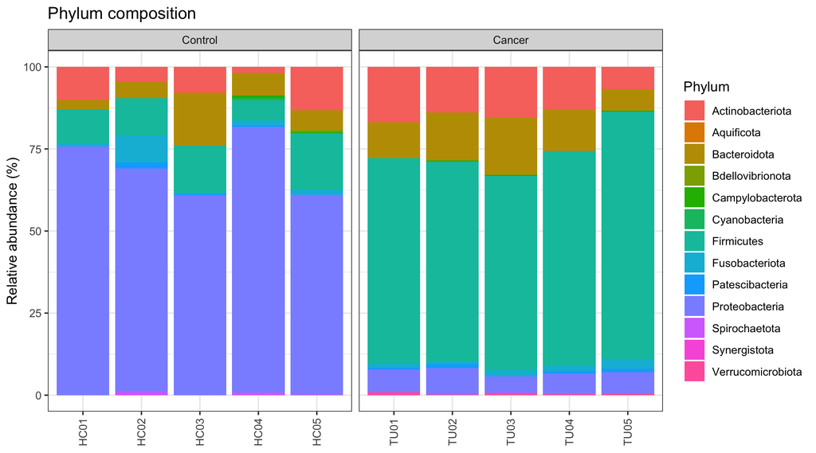

```r
# Additionner les ASV qui appartiennent au même phylum, puis convertir en pourcentages
ps_phylum <- tax_glom(ps_bact, taxrank = "Phylum")
ps_phylum_rel <- transform_sample_counts(ps_phylum, function(x) 100 * x / sum(x))

df_phylum <- psmelt(ps_phylum_rel)     # psmelt() fait un long tableau, facile pour ggplot

p_phylum <- ggplot(df_phylum, aes(x = Sample, y = Abundance, fill = Phylum)) +
  geom_bar(stat = "identity") +
  facet_wrap(~ group, scales = "free_x") +
  labs(title = "Phylum composition", y = "Relative abundance (%)", x = NULL) +
  theme_bw() + theme(axis.text.x = element_text(angle = 90, vjust = 0.5))
p_phylum
```

```r
save_figure(p_phylum, "composition_phylum", width = 10)
```

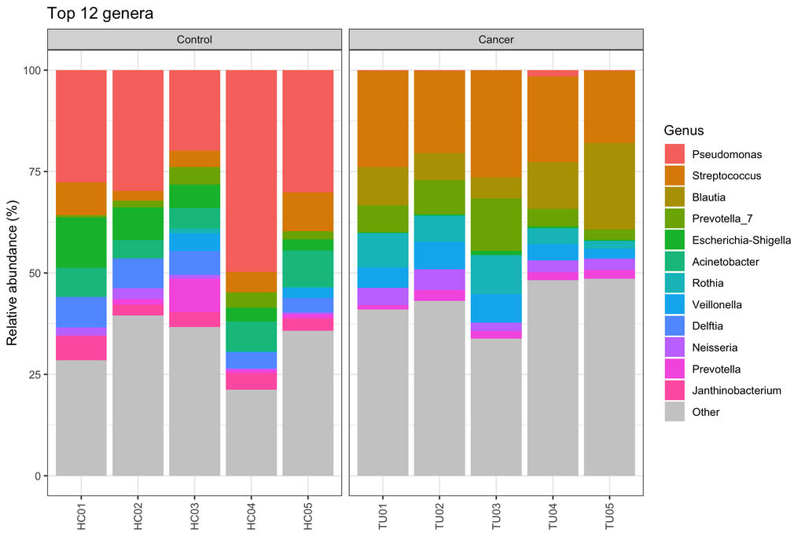

```r
# Niveau genre : on montre les 12 genres les plus abondants, les autres sont regroupés en "Other"
ps_genus <- tax_glom(ps_bact, taxrank = "Genus", NArm = FALSE)
ps_genus_rel <- transform_sample_counts(ps_genus, function(x) 100 * x / sum(x))
df_genus <- psmelt(ps_genus_rel)
df_genus$Genus[is.na(df_genus$Genus)] <- "Unclassified"

top_genera <- df_genus %>% group_by(Genus) %>% summarise(mean = mean(Abundance)) %>%
  arrange(desc(mean)) %>% filter(Genus != "Unclassified") %>% slice(1:12) %>% pull(Genus)
df_genus$Genus_plot <- ifelse(df_genus$Genus %in% top_genera, df_genus$Genus, "Other")
df_genus$Genus_plot <- factor(df_genus$Genus_plot, levels = c(top_genera, "Other"))

p_genus <- ggplot(df_genus, aes(x = Sample, y = Abundance, fill = Genus_plot)) +
  geom_bar(stat = "identity") +
  facet_wrap(~ group, scales = "free_x") +
  scale_fill_manual(values = c(scales::hue_pal()(12), "grey80")) +
  labs(title = "Top 12 genera", y = "Relative abundance (%)", x = NULL, fill = "Genus") +
  theme_bw() + theme(axis.text.x = element_text(angle = 90, vjust = 0.5))
p_genus
```

```r
save_figure(p_genus, "composition_genus", width = 11, height = 6)
```

**Comment lire ces graphiques :** chaque barre est un échantillon ; les couleurs montrent la part de chaque phylum ou genre. Comparez les deux panneaux : une bactérie est-elle clairement plus fréquente chez les patients ? Regardez aussi la **variabilité** à l’intérieur de chaque groupe : deux personnes du même groupe peuvent avoir des profils très différents.

```r
# Abondance relative moyenne (%) des genres principaux dans chaque groupe
df_genus %>% filter(Genus %in% top_genera) %>%
  group_by(Genus, group) %>% summarise(mean_percent = round(mean(Abundance), 1)) %>%
  tidyr::pivot_wider(names_from = group, values_from = mean_percent) %>%
  arrange(desc(Control + Cancer)) %>% knitr::kable()
```

| Genus | Control | Cancer |
| --- | --- | --- |
| Pseudomonas | 31.4 | 0.4 |
| Streptococcus | 5.8 | 21.9 |
| Blautia | 0.0 | 10.8 |
| Prevotella_7 | 2.5 | 7.0 |
| Escherichia-Shigella | 6.5 | 0.4 |
| Acinetobacter | 6.6 | 0.0 |
| Veillonella | 1.4 | 5.0 |
| Rothia | 0.3 | 6.1 |
| Delftia | 5.7 | 0.1 |
| Neisseria | 1.3 | 3.4 |
| Prevotella | 2.3 | 2.0 |
| Janthinobacterium | 3.9 | 0.0 |

> **Exercice d’observation : qui domine chez les témoins ?** Regardez les genres les plus abondants chez les témoins : *Pseudomonas*, *Acinetobacter*, *Delftia*, *Escherichia-Shigella*, *Janthinobacterium*… Beaucoup font partie du **“kitome”**, les bactéries des réactifs et des kits d’extraction. Les biopsies des témoins ont très peu d’ADN bactérien, donc ces contaminants y prennent une grande place. Chez les patients, on voit surtout des bactéries de la **bouche** (*Streptococcus*, *Prevotella*, *Veillonella*, *Rothia*)… et aussi des bactéries typiques de l’**intestin** (*Blautia*, *Ruminococcus*, *Bifidobacterium*), étonnantes dans une bronche. Question pour vous : les selles des mêmes patients ont été séquencées dans la même étude ; quelle explication technique pourrait-on imaginer ? (indice : contamination croisée entre échantillons pendant la préparation ou le séquençage).

> **Leçon principale :** une partie de la “différence” entre les groupes peut venir de la **quantité** d’ADN bactérien (faible chez les témoins) et de la contamination, et pas de la biologie du cancer.

# 6 Étape 5 - Diversité alpha : quelle diversité dans chaque échantillon ?

La **diversité alpha** décrit la diversité **à l’intérieur** d’un échantillon, comme la diversité des plantes dans **un seul** jardin :

- **Observed** = nombre d’ASV différents (la richesse) : combien d’espèces de plantes ;
- **Shannon** = richesse **et** équitabilité : les lectures sont-elles bien partagées entre ASV ? Un jardin avec 10 espèces en quantités égales est plus diversifié qu’un jardin avec 10 espèces où l’une couvre 95 % de la surface ;
- **Simpson** = probabilité que deux lectures tirées au hasard appartiennent à deux ASV différents (de 0 à 1).

## 6.1 Les indices de diversité : définitions et exemples

Il existe plusieurs indices, car chacun regarde le jardin d’une façon différente. Dans le tableau, **p** est la proportion d’un ASV dans l’échantillon (ses lectures divisées par le total), **S** le nombre d’ASV présents et **ln** le logarithme naturel.

| Indice | Ce qu’il mesure | Formule | Exemple de la vie courante |
| --- | --- | --- | --- |
| **Observed** (richesse, S) | le nombre d’ASV présents | S = nombre d’ASV avec au moins 1 lecture | compter les espèces de plantes d’un jardin, sans regarder combien il y a de pieds |
| **Chao1** | la richesse estimée, y compris les ASV rares jamais vus | S + F1² / (2 x F2), F1 = ASV vus 1 fois, F2 = vus 2 fois | estimer le nombre d’oiseaux d’une forêt à partir de ceux vus une ou deux fois seulement |
| **Shannon** (H) | la richesse **et** l’équilibre | H = -Σ p x ln(p) | une classe où tout le monde parle est plus “diverse” qu’une classe où un seul élève parle |
| **Pielou** (J) | l’équilibre seul, de 0 à 1 | J = H / ln(S) | 1 = toutes les espèces en même quantité |
| **Simpson** (1 - D) | la chance que 2 lectures tirées au hasard soient de 2 ASV différents | 1 - Σ p² | tirer 2 billes d’un sac : sont-elles de couleurs différentes ? |
| **Inverse Simpson** | le nombre “effectif” d’ASV | 1 / Σ p² | un jardin dominé par une espèce “vaut” moins d’espèces qu’il n’en contient |

**Attention à Chao1 avec DADA2 :** DADA2 retire les singletons (les séquences vues une seule fois). Chao1 a besoin d’eux : avec des ASV DADA2, Chao1 donne presque la même valeur qu’Observed et ne doit pas être interprété. C’est pourquoi nous ne l’utilisons pas ici.

**Un petit exemple à la main.** Deux jardins de 100 plantes ont les **mêmes 4 espèces**. Le jardin A est équilibré (25 plantes de chaque espèce) ; dans le jardin B, une espèce domine (85 roses et 5 plantes de chacune des autres). Calculons les indices nous-mêmes, puis avec le package vegan pour vérifier.

```r
# Deux jardins imaginaires de 100 plantes, avec les mêmes 4 espèces
jardins <- rbind(
  Jardin_A = c(Rose = 25, Jasmin = 25, Menthe = 25, Basilic = 25),   # équilibré
  Jardin_B = c(Rose = 85, Jasmin = 5,  Menthe = 5,  Basilic = 5))    # une espèce domine

# Proportions p : chaque ligne fait 1 (100 %)
p <- jardins / rowSums(jardins)
S <- rowSums(jardins > 0)                       # nombre d'espèces présentes

indices_exemple <- data.frame(
  Observed      = S,
  Shannon       = -rowSums(p * log(p)),             # H = -somme(p x ln p)
  Shannon_vegan = vegan::diversity(jardins, "shannon"),  # même résultat avec vegan
  Pielou        = -rowSums(p * log(p)) / log(S),     # équilibre de 0 à 1
  Simpson       = 1 - rowSums(p^2),                  # 1 - somme(p au carré)
  InvSimpson    = 1 / rowSums(p^2))                  # nombre "effectif" d'espèces
knitr::kable(round(indices_exemple, 2))
```

|  | Observed | Shannon | Shannon_vegan | Pielou | Simpson | InvSimpson |
| --- | --- | --- | --- | --- | --- | --- |
| Jardin_A | 4 | 1.39 | 1.39 | 1.00 | 0.75 | 4.00 |
| Jardin_B | 4 | 0.59 | 0.59 | 0.42 | 0.27 | 1.37 |

**Comment lire ce résultat :** les deux jardins ont la **même richesse** (Observed = 4), mais le jardin B est moins divers pour tous les autres indices : Shannon passe de 1,39 à 0,59, Pielou de 1 à 0,42, Simpson de 0,75 à 0,27, et l’Inverse Simpson dit que B “vaut” à peine 1,4 espèce. **Shannon** réagit surtout aux espèces rares, **Simpson** surtout aux espèces dominantes : c’est pourquoi on regarde souvent les deux. Dans nos biopsies, les mêmes indices sont calculés ci-dessous sur les ASV, exactement de la même manière.

## 6.2 Raréfaction

La richesse dépend de la profondeur : plus de lectures, plus d’ASV trouvés. Pour comparer équitablement, on **raréfie** : on tire au hasard le même nombre de lectures dans chaque échantillon (la plus petite profondeur). C’est comme demander aux deux pêcheurs de ne garder que leurs 50 premiers poissons avant de compter les espèces.

```r
min_depth <- min(sample_sums(ps_bact))
ps_rare <- rarefy_even_depth(ps_bact, sample.size = min_depth, rngseed = 123, verbose = FALSE)
cat("Every sample now has", min_depth, "reads. ASVs kept:", ntaxa(ps_rare), "\n")
```

```
## Every sample now has 347 reads. ASVs kept: 276
```

**Limite :** la raréfaction jette des lectures. Les résultats de diversité alpha sont donc indicatifs, surtout si la profondeur minimale est basse.

```r
alpha <- estimate_richness(ps_rare, measures = c("Observed", "Shannon", "Simpson"))
alpha$Sample <- rownames(alpha)
alpha$group  <- sample_data(ps_rare)$group
write.csv(alpha, file.path(out_dir, "alpha_diversity.csv"), row.names = FALSE)
knitr::kable(alpha[order(alpha$group), ], digits = 2, row.names = FALSE)
```

| Observed | Shannon | Simpson | Sample | group |
| --- | --- | --- | --- | --- |
| 34 | 2.97 | 0.93 | HC01 | Control |
| 44 | 3.23 | 0.94 | HC02 | Control |
| 58 | 3.65 | 0.96 | HC03 | Control |
| 49 | 2.95 | 0.88 | HC04 | Control |
| 59 | 3.49 | 0.94 | HC05 | Control |
| 85 | 3.96 | 0.97 | TU01 | Cancer |
| 94 | 3.98 | 0.97 | TU02 | Cancer |
| 85 | 3.84 | 0.96 | TU03 | Cancer |
| 89 | 4.08 | 0.97 | TU04 | Cancer |
| 84 | 3.99 | 0.97 | TU05 | Cancer |

## 6.3 Test entre deux groupes indépendants

Les deux groupes sont des personnes différentes, donc on utilise le **test de Wilcoxon-Mann- Whitney** (non apparié). Il range toutes les valeurs de la plus petite à la plus grande et regarde si un groupe se retrouve surtout en haut du classement. C’est comme un concours de course : si les 5 premiers à l’arrivée sont tous de la même équipe, ce n’est sûrement pas le hasard. Il ne suppose pas une distribution normale (gaussienne), ce qui est plus sûr avec seulement 5 personnes par groupe.

```r
alpha_tests <- data.frame()
for (index in c("Observed", "Shannon", "Simpson")) {
  control <- alpha[alpha$group == "Control", index]
  cancer  <- alpha[alpha$group == "Cancer",  index]
  test <- wilcox.test(cancer, control, exact = FALSE)
  alpha_tests <- rbind(alpha_tests, data.frame(
    Index = index,
    Median_control = round(median(control), 2),
    Median_cancer  = round(median(cancer), 2),
    p_value = signif(test$p.value, 3)))
}
knitr::kable(alpha_tests)
```

| Index | Median_control | Median_cancer | p_value |
| --- | --- | --- | --- |
| Observed | 49.00 | 85.00 | 0.0119 |
| Shannon | 3.23 | 3.98 | 0.0122 |
| Simpson | 0.94 | 0.97 | 0.0216 |

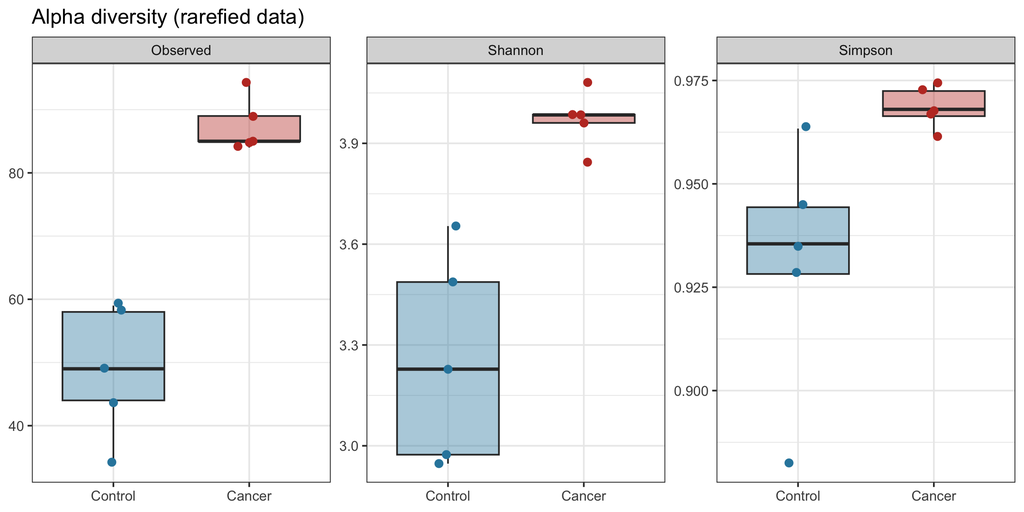

```r
alpha_long <- tidyr::pivot_longer(alpha, cols = c(Observed, Shannon, Simpson),
                                  names_to = "Index", values_to = "Value")
p_alpha <- ggplot(alpha_long, aes(x = group, y = Value)) +
  geom_boxplot(aes(fill = group), alpha = 0.4, outlier.shape = NA) +
  geom_jitter(aes(colour = group), width = 0.1, size = 2) +   # un point = une personne
  facet_wrap(~ Index, scales = "free_y") +
  scale_fill_manual(values = group_colours) + scale_colour_manual(values = group_colours) +
  labs(title = "Alpha diversity (rarefied data)", x = NULL, y = NULL) +
  theme_bw() + theme(legend.position = "none")
p_alpha
```

```r
save_figure(p_alpha, "alpha_diversity", width = 9, height = 4.5)
```

**Comment lire ce graphique :** chaque point est une personne. La boîte montre la médiane et la moitié centrale des valeurs. Une p-value sous 0,05 veut dire qu’une telle séparation entre les deux groupes serait rare si le hasard seul jouait. Avec 5 personnes par groupe, la plus petite p-value possible est environ 0,01 : il faut que les deux groupes soient presque complètement séparés.

# 7 Étape 6 - Diversité bêta : les communautés sont-elles différentes ?

La **diversité bêta** compare les échantillons **entre eux**, comme comparer deux jardins voisins. On utilise la **dissimilarité de Bray-Curtis** : 0 = deux échantillons ont exactement la même composition, 1 = ils n’ont rien en commun. On la calcule sur les abondances relatives, donc les différences de profondeur ne gênent pas.

Les deux mesures de diversité bêta les plus courantes :

| Mesure | Ce qu’elle compare | Formule | Exemple de la vie courante |
| --- | --- | --- | --- |
| **Bray-Curtis** | les abondances | 1 - 2 x (somme des minimums communs) / (total A + total B) | comparer deux paniers du marché en comptant les fruits de chaque sorte |
| **Jaccard** | la présence ou l’absence | 1 - (espèces communes) / (espèces au total) | comparer deux listes de courses, sans regarder les quantités |

Reprenons les deux jardins de l’étape 5 :

```r
# Bray-Curtis : tient compte du nombre de plantes de chaque espèce
vegan::vegdist(jardins, method = "bray")
```

```
##          Jardin_A
## Jardin_B      0.6
```

```r
# Jaccard (binary = TRUE) : seulement présence / absence des espèces
vegan::vegdist(jardins, method = "jaccard", binary = TRUE)
```

```
##          Jardin_A
## Jardin_B        0
```

**Comment lire ce résultat :** Bray-Curtis vaut **0,6** : les jardins sont assez différents, car l’un est dominé par les roses. Jaccard vaut **0** : les deux jardins ont exactement les mêmes espèces. Le choix de la mesure change donc la conclusion. Pour le microbiome, on utilise surtout Bray-Curtis (abondances) et on peut ajouter Jaccard pour voir si les **mêmes** bactéries sont présentes.

## 7.1 Ordination : PCoA et NMDS

Avec 10 échantillons, on a 45 distances par paires : illisible dans un tableau. Une **ordination** dessine les échantillons comme des points sur une carte en 2 dimensions, où les points proches ont des communautés similaires. C’est comme dessiner la carte de la Tunisie seulement à partir du tableau des distances entre villes : Tunis et Ariana seront proches, Tunis et Tozeur seront loin.

- **PCoA** (Analyse en Coordonnées Principales) : les axes montrent le % de variation qu’ils expliquent.
- **NMDS** : place les points en respectant l’**ordre** des distances ; le **stress** indique la qualité de la carte (< 0,2 est acceptable).

```r
ps_rel <- transform_sample_counts(ps_bact, function(x) x / sum(x))
bray   <- phyloseq::distance(ps_rel, method = "bray")

pcoa <- ordinate(ps_rel, method = "PCoA", distance = bray)
nmds <- ordinate(ps_rel, method = "NMDS", distance = bray, trace = FALSE)
```

```
## *** Best solution repeated 11 times
```

```r
cat("NMDS stress:", round(nmds$stress, 3), "\n")
```

```
## NMDS stress: 0
```

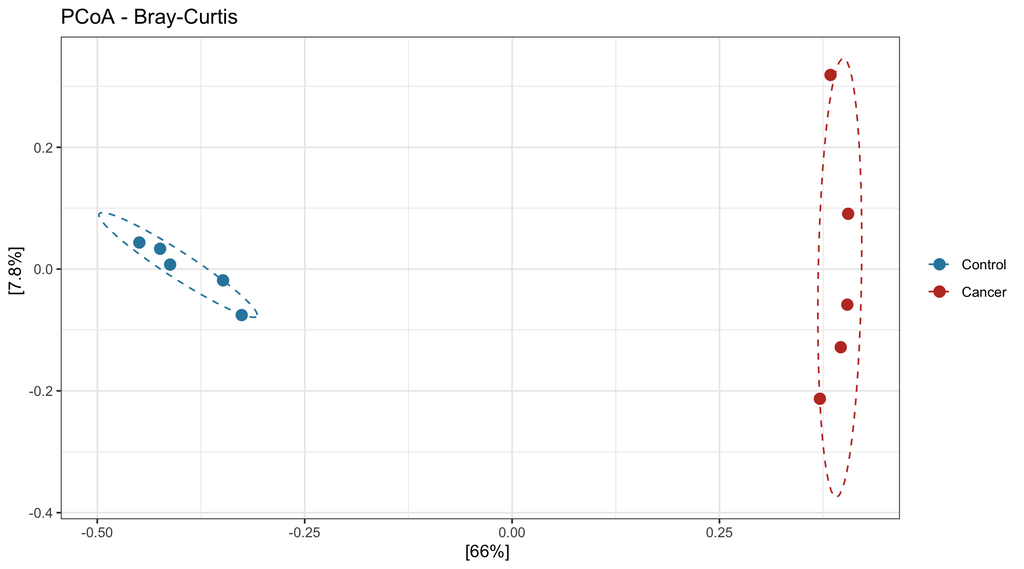

```r
p_pcoa <- plot_ordination(ps_rel, pcoa, color = "group") +
  geom_point(size = 3) + stat_ellipse(aes(group = group), type = "t", linetype = 2, level = 0.8) +
  scale_colour_manual(values = group_colours) +
  labs(title = "PCoA - Bray-Curtis", colour = NULL) + theme_bw()

p_nmds <- plot_ordination(ps_rel, nmds, color = "group") +
  geom_point(size = 3) + scale_colour_manual(values = group_colours) +
  labs(title = paste("NMDS - stress", round(nmds$stress, 2)), colour = NULL) + theme_bw()

p_pcoa
```

```r
save_figure(p_pcoa, "beta_diversity_PCoA", width = 7, height = 5)
```

**Comment lire ce graphique :** chaque point est un échantillon. Si les points rouges (cancer) et bleus (témoins) forment deux nuages séparés, les communautés diffèrent. Les ellipses en pointillé entourent environ 80 % de chaque groupe.

> **Et la NMDS ?** Regardez le stress affiché plus haut. S’il est proche de **0**, la NMDS a “trop bien” réussi : les deux groupes sont si séparés que la méthode écrase les points de chaque groupe les uns sur les autres. C’est comme une carte où toutes les villes du nord seraient dessinées au même endroit : la carte n’est plus utile. Dans ce cas, on montre seulement la PCoA (le graphique NMDS est gardé dans le code, `p_nmds`, pour comparer).

> **Pourquoi pas UniFrac ?** Les distances UniFrac utilisent un **arbre phylogénétique** des ASV. Nous n’avons pas construit d’arbre dans cet atelier, donc on utilise seulement Bray-Curtis. Ne calculez jamais UniFrac sans un arbre valide.

## 7.2 PERMANOVA : la différence est-elle significative ?

La **PERMANOVA** (`adonis2` dans vegan) teste si les groupes ont des **centres** différents dans l’espace des distances. Elle donne :

- **R²** = la part de la variation totale expliquée par le groupe (la **taille de l’effet**) ;
- la **p-value**, obtenue par **permutations** : on mélange les étiquettes “Cancer” et “Control” plusieurs fois, comme un tirage au sort, et on regarde si la vraie différence est plus grande que celles obtenues au hasard.

```r
meta_df <- data.frame(sample_data(ps_rel))

perm <- adonis2(bray ~ group, data = meta_df, permutations = 999)
perm
```

```
## Permutation test for adonis under reduced model
## Permutation: free
## Number of permutations: 999
##
## adonis2(formula = bray ~ group, data = meta_df, permutations = 999)
##          Df SumOfSqs      R2     F Pr(>F)
## Model     1   1.5380 0.65547 15.22   0.01 **
## Residual  8   0.8084 0.34453
## Total     9   2.3464 1.00000
## ---
## Signif. codes:  0 '***' 0.001 '**' 0.01 '*' 0.05 '.' 0.1 ' ' 1
```

**Comment lire ce résultat :** regardez les colonnes `R2` et `Pr(>F)` (p-value). Un R² de 0,30 voudrait dire que le groupe explique 30 % des différences entre échantillons ; le reste vient des différences entre personnes.

## 7.3 Test de dispersion (betadisper)

La PERMANOVA peut aussi donner un résultat significatif si un groupe est simplement **plus variable** (plus étalé) que l’autre, même avec le même centre. C’est comme deux classes avec la même moyenne de 12/20 : dans l’une toutes les notes sont entre 11 et 13, dans l’autre elles vont de 2 à 20. `betadisper` vérifie cela.

```r
disp <- betadisper(bray, meta_df$group)
permutest(disp, permutations = 999)
```

```
##
## Permutation test for homogeneity of multivariate dispersions
## Permutation: free
## Number of permutations: 999
##
## Response: Distances
##           Df    Sum Sq   Mean Sq      F N.Perm Pr(>F)
## Groups     1 0.0036527 0.0036527 1.0435    999  0.327
## Residuals  8 0.0280036 0.0035005
```

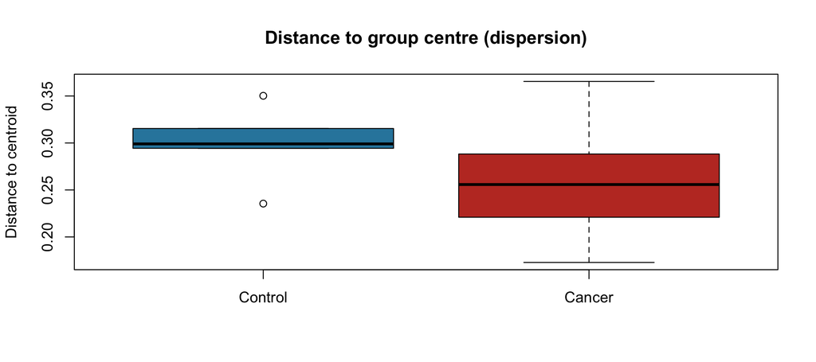

```r
boxplot(disp, col = group_colours, main = "Distance to group centre (dispersion)", xlab = "")
```

**Comment lire ce résultat :** si ce test n’est **pas** significatif (p > 0,05), les groupes ont un étalement semblable, et une PERMANOVA significative indique une vraie différence de composition. S’il **est** significatif, une partie du résultat de la PERMANOVA peut venir d’une variabilité différente.

# 8 Étape 7 - Quelles bactéries diffèrent ? (DESeq2)

**DESeq2** a été créé pour le RNA-seq mais il est souvent utilisé pour les données de **comptage** du microbiome. Il :

1. estime un **facteur de taille** par échantillon pour corriger la profondeur de séquençage (comme comparer les dépenses de deux familles en tenant compte de leurs revenus) ;
2. modélise les comptages avec une loi **binomiale négative** ;
3. teste chaque taxon et donne un **log2 fold change** (log2FC) et une p-value ajustée.

Les règles que nous suivons :

- DESeq2 a besoin des **comptages bruts**, jamais des abondances relatives ni des données raréfiées.
- Formule `~ group` : on compare les patients aux témoins.
- Niveau de référence = **Control**, donc log2FC > 0 veut dire **plus abondant chez les patients**.
- On travaille au niveau du **genre** et on garde les genres présents dans au moins 3 échantillons : tester des centaines d’ASV rares ajoute seulement du bruit.
- Comme on teste beaucoup de genres, les p-values sont corrigées pour les **tests multiples** (Benjamini-Hochberg, colonne `padj`). Acheter 100 billets de loterie augmente la chance de gagner par hasard : la correction en tient compte. On utilise `padj < 0.05`.

```r
ps_genus_counts <- tax_glom(ps_bact, taxrank = "Genus", NArm = TRUE)
keep <- genefilter_sample(ps_genus_counts, filterfun_sample(function(x) x > 0), A = 3)
ps_deseq <- prune_taxa(keep, ps_genus_counts)
cat("Genera tested:", ntaxa(ps_deseq), "\n")
```

```
## Genera tested: 75
```

```r
dds <- phyloseq_to_deseq2(ps_deseq, ~ group)

# Facteurs de taille "poscounts" : recommandés pour le microbiome, qui contient beaucoup de zéros
dds <- estimateSizeFactors(dds, type = "poscounts")
dds <- tryCatch(DESeq(dds, fitType = "parametric", quiet = TRUE),
                error = function(e) DESeq(dds, fitType = "mean", quiet = TRUE))

res <- results(dds, contrast = c("group", "Cancer", "Control"), alpha = 0.05)
summary(res)
```

```
##
## out of 75 with nonzero total read count
## adjusted p-value < 0.05
## LFC > 0 (up)       : 38, 51%
## LFC < 0 (down)     : 17, 23%
## outliers [1]       : 0, 0%
## low counts [2]     : 0, 0%
## (mean count < 1)
## [1] see 'cooksCutoff' argument of ?results
## [2] see 'independentFiltering' argument of ?results
```

```r
res_df <- data.frame(res)
res_df$Genus  <- as.character(tax_table(ps_deseq)[rownames(res_df), "Genus"])
res_df$Phylum <- as.character(tax_table(ps_deseq)[rownames(res_df), "Phylum"])
res_df <- res_df[order(res_df$pvalue), c("Genus", "Phylum", "baseMean",
                                         "log2FoldChange", "lfcSE", "pvalue", "padj")]
write.csv(res_df, file.path(out_dir, "DESeq2_genus_Cancer_vs_Control.csv"))

knitr::kable(head(res_df, 15), digits = 3, row.names = FALSE,
             caption = "15 genera with the smallest p-values")
```

15 genera with the smallest p-values

| Genus | Phylum | baseMean | log2FoldChange | lfcSE | pvalue | padj |
| --- | --- | --- | --- | --- | --- | --- |
| Blautia | Firmicutes | 98.456 | 9.858 | 1.082 | 0 | 0 |
| Delftia | Proteobacteria | 26.591 | -5.221 | 0.635 | 0 | 0 |
| Acinetobacter | Proteobacteria | 37.296 | -8.872 | 1.150 | 0 | 0 |
| Janthinobacterium | Proteobacteria | 19.523 | -7.948 | 1.074 | 0 | 0 |
| [Eubacterium] hallii group | Firmicutes | 15.584 | 7.196 | 1.008 | 0 | 0 |
| Ruminococcus | Firmicutes | 16.275 | 7.258 | 1.045 | 0 | 0 |
| Bifidobacterium | Actinobacteriota | 19.759 | 6.943 | 1.066 | 0 | 0 |
| Pseudomonas | Proteobacteria | 182.577 | -5.673 | 0.876 | 0 | 0 |
| Allorhizobium-Neorhizobium-Pararhizobium-Rhizobium | Proteobacteria | 9.869 | -6.943 | 1.078 | 0 | 0 |
| Subdoligranulum | Firmicutes | 9.515 | 6.487 | 1.016 | 0 | 0 |
| Neisseria | Proteobacteria | 35.317 | 2.707 | 0.434 | 0 | 0 |
| Dorea | Firmicutes | 10.365 | 6.607 | 1.065 | 0 | 0 |
| Holdemanella | Firmicutes | 9.416 | 6.469 | 1.094 | 0 | 0 |
| Atopobium | Actinobacteriota | 7.834 | 6.213 | 1.094 | 0 | 0 |
| Sphingomonas | Proteobacteria | 5.198 | -6.025 | 1.068 | 0 | 0 |

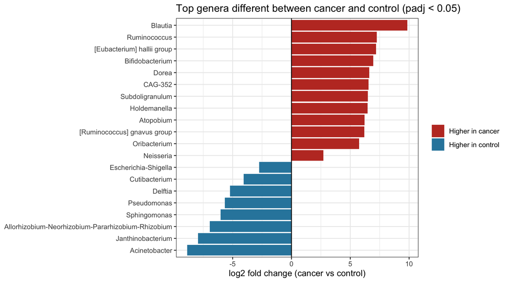

```r
sig <- res_df[!is.na(res_df$padj) & res_df$padj < 0.05, ]

if (nrow(sig) > 0) {
  sig$Direction <- ifelse(sig$log2FoldChange > 0, "Higher in cancer", "Higher in control")
  sig_plot <- head(sig[order(sig$padj), ], 20)   # au maximum les 20 genres les plus significatifs
  p_deseq <- ggplot(sig_plot, aes(x = log2FoldChange, y = reorder(Genus, log2FoldChange),
                             fill = Direction)) +
    geom_col() + geom_vline(xintercept = 0) +
    scale_fill_manual(values = c("Higher in cancer" = "#C0392B", "Higher in control" = "#2E86AB")) +
    labs(title = "Top genera different between cancer and control (padj < 0.05)",
         x = "log2 fold change (cancer vs control)", y = NULL, fill = NULL) + theme_bw()
} else {
  # Aucun genre significatif : on montre à la place le "volcano plot" de tous les genres testés
  p_deseq <- ggplot(res_df, aes(x = log2FoldChange, y = -log10(pvalue))) +
    geom_point(colour = "grey40") +
    geom_hline(yintercept = -log10(0.05), linetype = "dashed") +
    labs(title = "Volcano plot - no genus with padj < 0.05",
         x = "log2 fold change (cancer vs control)", y = "-log10(p-value)") + theme_bw()
}
p_deseq
```

```r
save_figure(p_deseq, "DESeq2_genus", width = 8, height = 5)
```

**Comment lire ce résultat :**

- `log2FoldChange` = 1 veut dire **2 fois** plus chez les patients ; -1 veut dire 2 fois moins ; 3 veut dire 8 fois plus (2 x 2 x 2).
- `padj` est la p-value corrigée pour les nombreux tests. Seul `padj < 0.05` est considéré comme significatif.
- 55 genre(s) sur 75 atteignent `padj < 0.05` dans cette analyse.

> **Trop beau pour être vrai ?** Si une grande partie des genres testés sort “significative”, il faut se méfier, pas se réjouir. Ici trois raisons l’expliquent : (1) les échantillons ont été **choisis** pour être différents ; (2) les témoins ont **beaucoup moins** de lectures bactériennes que les patients ; (3) les données sont **compositionnelles** : si un genre augmente beaucoup, tous les autres paraissent changer. C’est comme un thermomètre qui afficherait 40 °C dans toutes les pièces de la maison : on vérifie d’abord le thermomètre.

## 8.1 Vérifier avant de croire : qui porte ces genres ?

Une petite p-value ajustée **ne suffit pas**. Avec seulement 5 personnes par groupe et beaucoup de zéros, une seule personne avec un comptage très élevé peut produire un résultat “significatif” et un fold change énorme (un log2FC de 10 ou plus veut dire plus de 1 000 fois). C’est comme la moyenne de richesse d’un café où entre un milliardaire : la moyenne explose, mais personne d’autre n’est devenu riche. Pour chaque genre significatif, on regarde les données brutes : dans combien d’échantillons il est présent, et avec quelle abondance ?

```r
if (nrow(sig) > 0) {
  ps_genus_rel_check <- transform_sample_counts(ps_deseq, function(x) 100 * x / sum(x))
  check <- data.frame()
  for (id in rownames(sig)) {
    counts <- as.numeric(otu_table(ps_deseq)[, id])
    pct    <- as.numeric(otu_table(ps_genus_rel_check)[, id])
    grp    <- sample_data(ps_deseq)$group
    check <- rbind(check, data.frame(
      Genus = sig[id, "Genus"],
      log2FC = round(sig[id, "log2FoldChange"], 1),
      Present_in_cancer  = sum(counts[grp == "Cancer"]  > 0),
      Present_in_control = sum(counts[grp == "Control"] > 0),
      Max_percent_in_one_sample = round(max(pct), 1),
      Sample_with_max = sample_names(ps_deseq)[which.max(pct)]))
  }
  knitr::kable(head(check[order(-abs(check$log2FC)), ], 10), row.names = FALSE,
               caption = "10 significant genera with the largest fold changes")
}
```

10 significant genera with the largest fold changes

| Genus | log2FC | Present_in_cancer | Present_in_control | Max_percent_in_one_sample | Sample_with_max |
| --- | --- | --- | --- | --- | --- |
| Blautia | 9.9 | 5 | 0 | 23.4 | TU05 |
| Acinetobacter | -8.9 | 0 | 5 | 9.5 | HC05 |
| Janthinobacterium | -7.9 | 0 | 5 | 6.2 | HC01 |
| Ruminococcus | 7.3 | 5 | 0 | 3.3 | TU05 |
| [Eubacterium] hallii group | 7.2 | 5 | 0 | 2.6 | TU05 |
| Undibacterium | -7.1 | 0 | 4 | 5.3 | HC03 |
| Bifidobacterium | 6.9 | 5 | 1 | 4.7 | TU04 |
| Allorhizobium-Neorhizobium-Pararhizobium-Rhizobium | -6.9 | 0 | 5 | 5.7 | HC02 |
| Dorea | 6.6 | 5 | 0 | 1.8 | TU04 |
| CAG-352 | 6.6 | 5 | 0 | 3.0 | TU02 |

**Comment lire ce tableau :** un genre présent dans peu d’échantillons, ou dominé par un seul échantillon, donne un résultat fragile. Posez deux questions :

1. **Le résultat vient-il d’une seule personne ?** Si la plupart des lectures viennent d’un échantillon, la “différence” décrit peut-être cette personne, pas le cancer du poumon.
2. **Est-ce un contaminant connu ?** Certains genres sont souvent trouvés dans les kits d’extraction d’ADN et les réactifs de PCR, le fameux **“kitome”**, par exemple *Bradyrhizobium*, *Ralstonia*, *Burkholderia*, *Sphingomonas*, *Methylobacterium* ou *Pseudomonas*. Les contaminants sont typiquement **plus abondants dans les échantillons avec le moins de lectures** : moins il y a de vrai ADN bactérien, plus l’ADN des réactifs pèse lourd. C’est comme une pincée de sel : invisible dans une grande marmite, mais très forte dans une petite tasse.

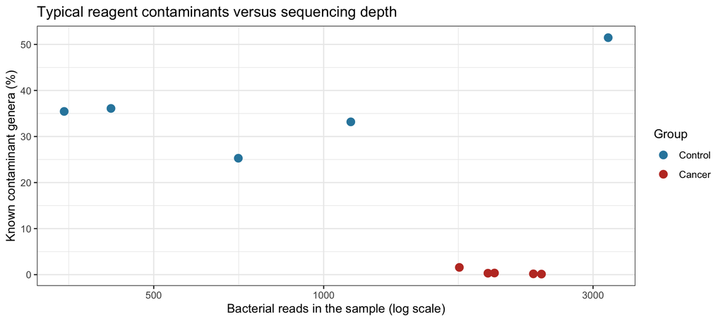

```r
# Abondance relative des contaminants typiques en fonction de la profondeur de séquençage
kitome <- c("Bradyrhizobium", "Ralstonia", "Burkholderia-Caballeronia-Paraburkholderia",
            "Sphingomonas", "Methylobacterium-Methylorubrum", "Pseudomonas", "Cutibacterium")
ps_genus_all_rel <- transform_sample_counts(ps_genus_counts, function(x) 100 * x / sum(x))
is_kitome <- tax_table(ps_genus_all_rel)[, "Genus"] %in% kitome
kit_df <- data.frame(Sample = sample_names(ps_genus_all_rel),
                     Group  = sample_data(ps_genus_all_rel)$group,
                     Reads  = sample_sums(ps_bact),
                     Kitome_percent = colSums(t(otu_table(ps_genus_all_rel))[is_kitome, , drop = FALSE]))
p_kit <- ggplot(kit_df, aes(x = Reads, y = Kitome_percent, colour = Group)) +
  geom_point(size = 3) + scale_x_log10() + scale_colour_manual(values = group_colours) +
  labs(title = "Typical reagent contaminants versus sequencing depth",
       x = "Bacterial reads in the sample (log scale)", y = "Known contaminant genera (%)") +
  theme_bw()
p_kit
```

```r
save_figure(p_kit, "contaminants_vs_depth", width = 7, height = 4)
cor.test(log10(kit_df$Reads), kit_df$Kitome_percent, method = "spearman", exact = FALSE)
```

```
##
##  Spearman's rank correlation rho
##
## data:  log10(kit_df$Reads) and kit_df$Kitome_percent
## S = 234, p-value = 0.2291
## alternative hypothesis: true rho is not equal to 0
## sample estimates:
##        rho
## -0.4181818
```

**Comment lire ce graphique :** si les points descendent de gauche à droite (plus de contaminants dans les échantillons avec moins de lectures, corrélation négative), une partie du signal est probablement une contamination par les réactifs. C’est exactement pourquoi les études à faible biomasse **doivent** séquencer et analyser des témoins négatifs (avec `decontam`).

**Limites de DESeq2 pour le microbiome :** les données de microbiome sont **compositionnelles** (des pourcentages qui font 100 % au total). C’est comme une pizza : si une part grandit, les autres paraissent plus petites, même si elles n’ont pas changé. Elles sont aussi très creuses (beaucoup de zéros) et, ici, à faible biomasse. Les résultats doivent être confirmés par une autre méthode (par exemple ANCOM-BC ou ALDEx2) et dans une cohorte indépendante.

# 9 Étape 8 - Interprétation biologique : prudence !

**Ce que nous pouvons dire :** dans ces 10 biopsies bronchiques, nous avons décrit les différences de diversité et de composition entre 5 patients atteints de cancer du poumon et 5 témoins sans cancer, et nous avons appris à vérifier chaque résultat.

**Ce que nous ne pouvons pas dire :**

1. **Les échantillons ont été choisis pour montrer une différence.** Parmi 41 biopsies, nous avons gardé les 10 qui séparent le mieux les groupes. C’est comme juger une équipe de football en ne regardant que ses 5 plus beaux buts : la différence est exagérée. Les p-values de cet atelier ne sont **pas** des résultats scientifiques. Pour conclure, il faut analyser **tous** les échantillons, choisis **avant** de regarder les résultats.
2. **Association n’est pas causalité.** Il y a plus de pompiers sur les grands incendies, mais les pompiers ne causent pas les incendies. Une bactérie plus abondante chez les patients peut être une *conséquence* de la tumeur (oxygène, mucus, nécrose différents), pas une cause.
3. **Pas un biomarqueur.** 5 personnes par groupe, c’est un très petit jeu de données. Un biomarqueur demande de grandes cohortes, une validation dans des populations indépendantes et des essais cliniques.
4. **Faible biomasse et contamination.** Une biopsie bronchique contient très peu d’ADN bactérien. Sans témoins négatifs (decontam), certaines “bactéries” peuvent être des contaminants des réactifs.
5. **Bactéries orales.** Des genres comme *Streptococcus*, *Prevotella* ou *Veillonella* sont typiques de la bouche. Ils atteignent les bronches par micro-aspiration (une vraie voie biologique), mais aussi par le bronchoscope, qui passe par la bouche.
6. **Facteurs de confusion.** Les patients et les témoins sont des personnes différentes : le **tabac**, l’âge, le sexe, les antibiotiques, la BPCO ou la raison de la bronchoscopie chez les témoins peuvent tous expliquer une partie des différences. Ici, nous n’avons pas ces informations : c’est une limite importante.
7. **Le 16S ne mesure pas la fonction.** Nous savons *qui* est là (souvent seulement au niveau du genre), pas *ce qu’ils font*. C’est comme connaître la liste des habitants d’un immeuble sans connaître leur métier. Les questions de fonction demandent la métagénomique shotgun ou la métatranscriptomique.
8. **Ne pas mélanger les types d’échantillons.** Biopsie bronchique, liquide de LBA, crachat et selles ont des biomasses et des communautés complètement différentes. Ils doivent être analysés séparément.

# 10 Résumé de la partie 2

```
##                              Analysis               Result
## 1          Samples (Cancer / Control)                5 / 5
## 2                 ASVs after cleaning                  340
## 3 Alpha diversity (Wilcoxon, Shannon)           p = 0.0122
## 4         PERMANOVA cancer vs control R2 = 0.655, p = 0.01
## 5           Genera tested with DESeq2                   75
## 6             Genera with padj < 0.05                   55
```

```r
saveRDS(ps_bact, file.path(out_dir, "phyloseq_bacteria.rds"))
list.files(out_dir); list.files(fig_dir)
```

```
## [1] "alpha_diversity.csv"                "DESeq2_genus_Cancer_vs_Control.csv"
## [3] "phyloseq_bacteria.rds"
```

```
##  [1] "alpha_diversity.pdf"       "alpha_diversity.png"
##  [3] "beta_diversity_PCoA.pdf"   "beta_diversity_PCoA.png"
##  [5] "composition_genus.pdf"     "composition_genus.png"
##  [7] "composition_phylum.pdf"    "composition_phylum.png"
##  [9] "contaminants_vs_depth.pdf" "contaminants_vs_depth.png"
## [11] "DESeq2_genus.pdf"          "DESeq2_genus.png"
```

# 11 Versions des logiciels